# Untitled

Reyzha Siva Dewi

2023-12-16

# Praktikum 1

```r
library("forecast")
```

```r
library("graphics")
library("TTR")
library("TSA")
```

## Impor Data

```r
library("readxl")
dt <- read_xlsx("E:/Semester 5/MPDW/Jumlah Penumpang Kereta Api (1).xlsx")
View(dt)
str(dt)
```

```
## tibble [144 × 2] (S3: tbl_df/tbl/data.frame)
##  $ Periode                  : chr [1:144] "Januari 2011" "Februari 2011" "Maret 2011" "April 2011" ...
##  $ Jumlah Penumpang KAI Jawa: num [1:144] 16446 14519 16584 16031 17018 ...
```

```r
dim(dt)
```

```
## [1] 144   2
```

```r
data <- dt[1:110,]
View(data)
dim(data)
```

```
## [1] 110   2
```

Mengubah data agar terbaca sebagai data deret waktu dengan fungsi `ts()` .

```r
data.ts <- ts(data$`Jumlah Penumpang KAI Jawa`)
summary(data.ts)
```

```
##    Min. 1st Qu.  Median    Mean 3rd Qu.    Max.
##   14315   17646   27098   25715   32935   38303
```

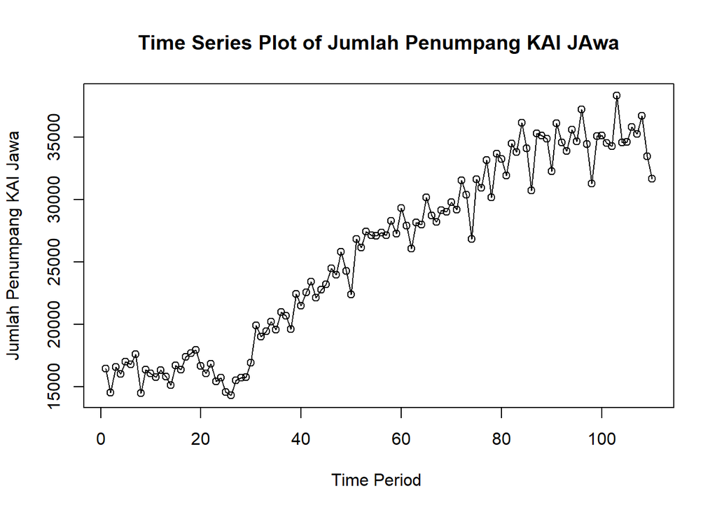

```r
ts.plot(data.ts, xlab="Time Period ", ylab="Jumlah Penumpang KAI Jawa",
        main = "Time Series Plot of Jumlah Penumpang KAI JAwa")
points(data.ts)
```

## Single Moving Average & Double Moving Average

### Pembagian Data**

Pembagian data latih dan data uji dilakukan dengan perbandingan 80% data latih dan 20% data uji.

```r
#Membagi data latih dan data uji
training_ma <- data[1:88,]
testing_ma <- data[89:110,]
train_ma.ts <- ts(training_ma$`Jumlah Penumpang KAI Jawa`)
test_ma.ts <- ts(testing_ma$`Jumlah Penumpang KAI Jawa`)
```

### Eksplorasi Data

Eksplorasi data dilakukan pada keseluruhan data, data latih serta data uji menggunakan plot data deret waktu.

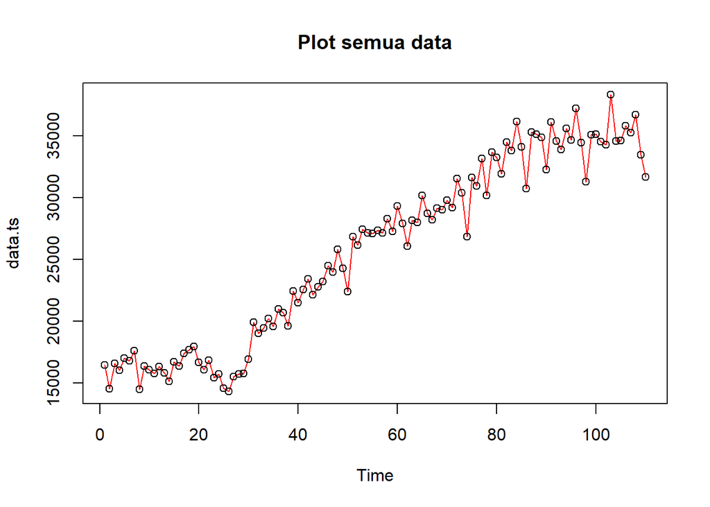

```r
#Eksplorasi keseluruhan data
plot(data.ts, col="red", main = "Plot semua data")
points(data.ts)
```

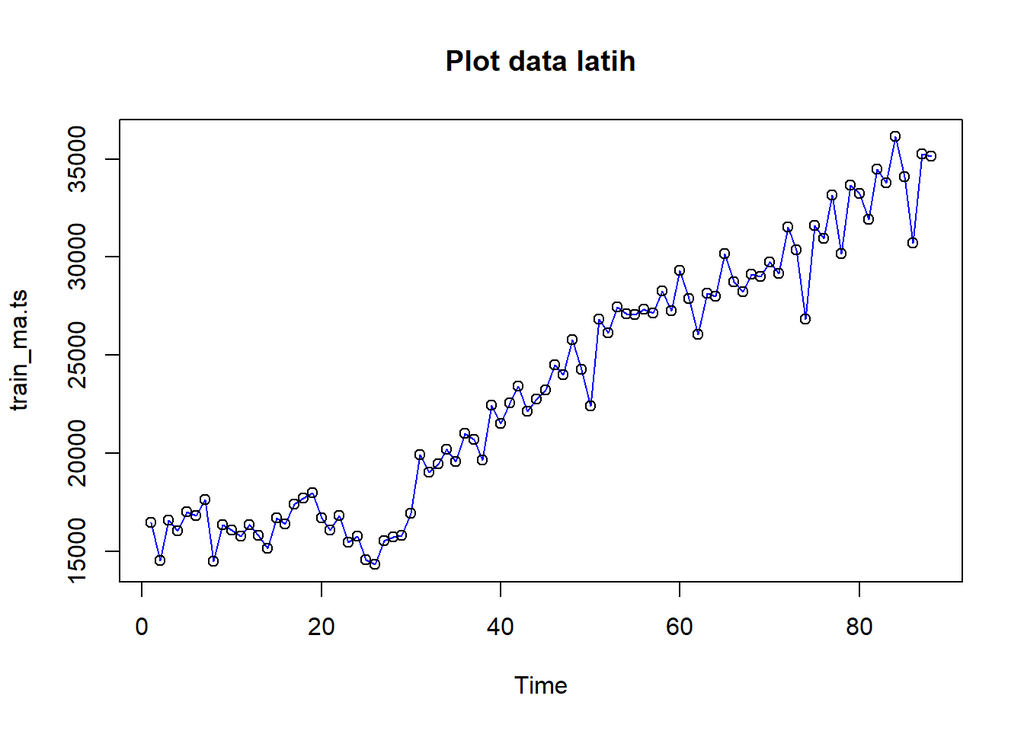

```r
#Eksplorasi data latih
plot(train_ma.ts, col = "blue", main = "Plot data latih")
points(train_ma.ts)
```

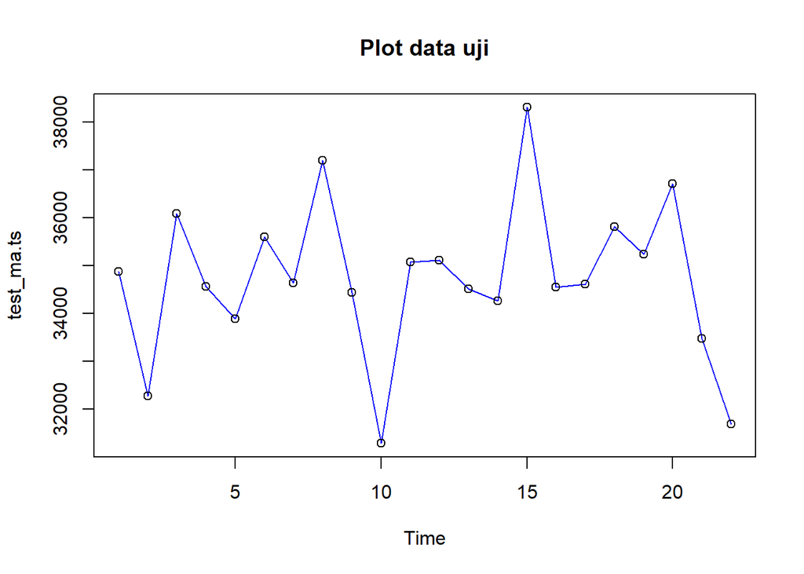

```r
#Eksplorasi data uji
plot(test_ma.ts, col="blue", main="Plot data uji")
points(test_ma.ts)
```

Kesimpulan:

Pada plot di atas terbentuk plot data tren sehingga untuk pemulusan sebaiknya menggunaka Double Moving Average dan DES dari ke empat uji yang ada.

### Single Moving Average (SMA)

Ide dasar dari Single Moving Average (SMA) adalah data suatu periode dipengaruhi oleh data periode sebelumnya. Metode pemulusan ini cocok digunakan untuk pola data stasioner atau konstan. Prinsip dasar metode pemulusan ini adalah data pemulusan pada periode ke-t merupakan rata rata dari m buah data pada periode ke-t hingga periode ke (t-m+1). Data pemulusan pada periode ke-t selanjutnya digunakan sebagai nilai peramalan pada periode ke t+1

Pemulusan menggunakan metode SMA dilakukan dengan fungsi `SMA()`. Dalam hal ini akan dilakukan pemulusan dengan parameter `m=2`.

```r
library(TTR)
data.sma<-SMA(train_ma.ts, n=2)
data.sma
```

```
## Time Series:
## Start = 1
## End = 88
## Frequency = 1
##  [1]      NA 15482.5 15551.5 16307.5 16524.5 16912.0 17219.0 16062.0 15422.5
## [10] 16207.5 15913.5 16049.0 16067.0 15463.5 15913.5 16538.5 16888.5 17544.0
## [19] 17821.5 17315.5 16369.0 16445.5 16132.0 15590.5 15159.0 14444.0 14918.0
## [28] 15622.5 15759.5 16363.5 18424.5 19474.0 19235.0 19818.5 19888.0 20285.0
## [37] 20845.0 20163.0 21027.5 21964.5 22024.5 22981.0 22770.0 22444.0 22991.0
## [46] 23861.0 24244.5 24888.5 25022.5 23324.0 24617.5 26495.5 26800.0 27284.0
## [55] 27097.5 27214.0 27238.0 27702.5 27766.5 28290.5 28607.0 26972.0 27107.0
## [64] 28078.0 29088.0 29453.0 28473.0 28670.5 29072.0 29392.0 29471.5 30354.0
## [73] 30944.5 28598.0 29224.5 31273.0 32045.5 31669.0 31925.0 33462.0 32588.0
## [82] 33209.5 34148.0 34969.0 35123.5 32414.0 32996.5 35203.5
```

Data pemulusan pada periode ke-t selanjutnya digunakan sebagai nilai peramalan pada periode ke t+1 sehingga hasil peramalan 1 periode kedepan adalah sebagai berikut.

```r
data.ramal <- c(NA, data.sma)
data.ramal <- c(NA, data.sma)
```

```r
data.gab <- cbind(aktual=c(train_ma.ts,rep(NA,13)),pemulusan=c(data.sma,rep(NA,13)),ramalan=c(data.ramal,rep(data.ramal[length(data.ramal)],12)))

data.gab #forecast 13 periode ke depan
```

```
##        aktual pemulusan ramalan
##   [1,]  16446        NA      NA
##   [2,]  14519   15482.5      NA
##   [3,]  16584   15551.5 15482.5
##   [4,]  16031   16307.5 15551.5
##   [5,]  17018   16524.5 16307.5
##   [6,]  16806   16912.0 16524.5
##   [7,]  17632   17219.0 16912.0
##   [8,]  14492   16062.0 17219.0
##   [9,]  16353   15422.5 16062.0
##  [10,]  16062   16207.5 15422.5
##  [11,]  15765   15913.5 16207.5
##  [12,]  16333   16049.0 15913.5
##  [13,]  15801   16067.0 16049.0
##  [14,]  15126   15463.5 16067.0
```

[output cut: 87 more lines]

Adapun plot data deret waktu dari hasil peramalan yang dilakukan adalah sebagai berikut.

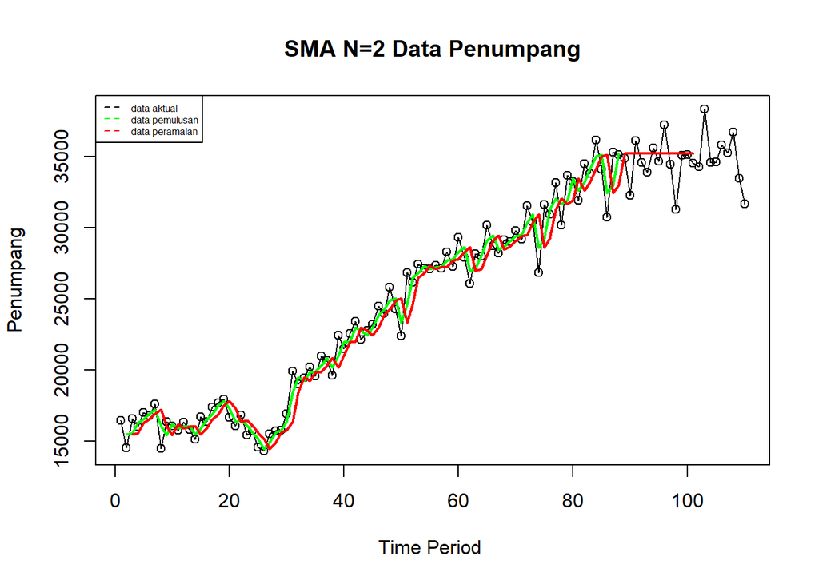

```r
ts.plot(data.ts, xlab="Time Period ", ylab="Penumpang", main= "SMA N=2 Data Penumpang")

points(data.ts)

lines(data.gab[,2],col="green",lwd=2)

lines(data.gab[,3],col="red",lwd=2)

legend("topleft",c("data aktual","data pemulusan","data peramalan"), lty=8, col=c("black","green","red"), cex=0.5)
```

Selanjutnya perhitungan akurasi dilakukan dengan ukuran akurasi *Sum Squares Error* (SSE), *Mean Square Error* (MSE) dan *Mean Absolute Percentage Error* (MAPE). Perhitungan akurasi dilakukan baik pada data latih maupun pada data uji.

```r
#Menghitung nilai keakuratan data latih

error_train.sma = train_ma.ts-data.ramal[1:length(train_ma.ts)]

SSE_train.sma = sum(error_train.sma[5:length(train_ma.ts)]^2)

MSE_train.sma = mean(error_train.sma[5:length(train_ma.ts)]^2)

MAPE_train.sma = mean(abs((error_train.sma[5:length(train_ma.ts)]/train_ma.ts[5:length(train_ma.ts)])*100))

akurasi_train.sma <- matrix(c(SSE_train.sma, MSE_train.sma, MAPE_train.sma))

row.names(akurasi_train.sma)<- c("SSE", "MSE", "MAPE")

colnames(akurasi_train.sma) <- c("Akurasi m = 2")

akurasi_train.sma
```

```
##      Akurasi m = 2
## SSE   1.853645e+08
## MSE   2.206721e+06
## MAPE  4.835414e+00
```

[output not shown]

```r
SSE_test.sma = sum(error_test.sma^2)

MSE_test.sma = mean(error_test.sma^2)

MAPE_test.sma = mean(abs((error_test.sma/test_ma.ts*100)))

akurasi_test.sma <- matrix(c(SSE_test.sma, MSE_test.sma, MAPE_test.sma))

row.names(akurasi_test.sma)<- c("SSE", "MSE", "MAPE")

colnames(akurasi_test.sma) <- c("Akurasi m = 2")

akurasi_test.sma
```

```
##      Akurasi m = 2
## SSE   6.193514e+07
## MSE   2.815234e+06
## MAPE  3.656062e+00
```

Kesimpulan hasil SMA:

Perhitungan akurasi menggunakan data latih menghasilkan nilai MAPE yang kurang dari 10% sehingga nilai akurasi ini dapat dikategorikan sebagai sangat baik.

### Double Moving Average (DMA)

Metode pemulusan Double Moving Average (DMA) pada dasarnya mirip dengan SMA. Namun demikian, metode ini lebih cocok digunakan untuk pola data trend. Proses pemulusan dengan rata rata dalam metode ini dilakukan sebanyak 2 kali.

```r
dma <- SMA(data.sma, n = 2)

At <- 2*data.sma - dma

Bt <- 2/(4-1)*(data.sma - dma)

data.dma<- At+Bt

data.ramal2<- c(NA, data.dma)

t = 1:24

f = c()

for (i in t) {

  f[i] = At[length(At)] + Bt[length(Bt)]*(i)

}

data.gab2 <- cbind(aktual = c(train_ma.ts,rep(NA,24)), pemulusan1 = c(data.sma,rep(NA,24)),pemulusan2 = c(data.dma, rep(NA,24)),At = c(At, rep(NA,24)), Bt = c(Bt,rep(NA,24)),ramalan = c(data.ramal2, f[-1]))

data.gab2
```

```
##        aktual pemulusan1 pemulusan2       At         Bt  ramalan
##   [1,]  16446         NA         NA       NA         NA       NA
##   [2,]  14519    15482.5         NA       NA         NA       NA
##   [3,]  16584    15551.5   15609.00 15586.00   23.00000       NA
##   [4,]  16031    16307.5   16937.50 16685.50  252.00000 15609.00
##   [5,]  17018    16524.5   16705.33 16633.00   72.33333 16937.50
##   [6,]  16806    16912.0   17234.92 17105.75  129.16667 16705.33
##   [7,]  17632    17219.0   17474.83 17372.50  102.33333 17234.92
##   [8,]  14492    16062.0   15097.83 15483.50 -385.66667 17474.83
##   [9,]  16353    15422.5   14889.58 15102.75 -213.16667 15097.83
##  [10,]  16062    16207.5   16861.67 16600.00  261.66667 14889.58
##  [11,]  15765    15913.5   15668.50 15766.50  -98.00000 16861.67
##  [12,]  16333    16049.0   16161.92 16116.75   45.16667 15668.50
##  [13,]  15801    16067.0   16082.00 16076.00    6.00000 16161.92
##  [14,]  15126    15463.5   14960.58 15161.75 -201.16667 16082.00
```

[output cut: 98 more lines]

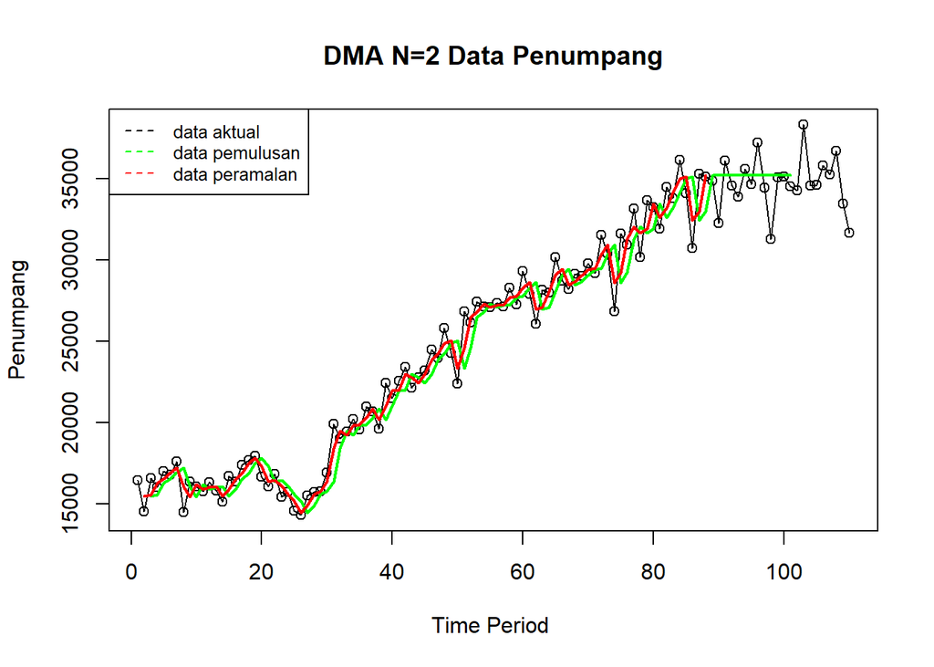

```r
ts.plot(data.ts, xlab="Time Period ", ylab="Penumpang", main= "DMA N=2 Data Penumpang")

points(data.ts)

lines(data.gab[,3],col="green",lwd=2)

lines(data.gab[,2],col="red",lwd=2)

legend("topleft",c("data aktual","data pemulusan","data peramalan"), lty=8, col=c("black","green","red"), cex=0.8)
```

Selanjutnya perhitungan akurasi dilakukan baik pada data latih maupun data uji. Perhitungan akurasi dilakukan dengan ukuran akurasi SSE, MSE dan MAPE.

```r
#Menghitung nilai keakuratan data latih

error_train.dma = train_ma.ts-data.ramal2[1:length(train_ma.ts)]

SSE_train.dma = sum(error_train.dma[8:length(train_ma.ts)]^2)

MSE_train.dma = mean(error_train.dma[8:length(train_ma.ts)]^2)

MAPE_train.dma = mean(abs((error_train.dma[8:length(train_ma.ts)]/train_ma.ts[8:length(train_ma.ts)])*100))

akurasi_train.dma <- matrix(c(SSE_train.dma, MSE_train.dma, MAPE_train.dma))

row.names(akurasi_train.dma)<- c("SSE", "MSE", "MAPE")

colnames(akurasi_train.dma) <- c("Akurasi m = 4")

akurasi_train.dma
```

```
##      Akurasi m = 4
## SSE   2.570595e+08
## MSE   3.173575e+06
## MAPE  5.565344e+00
```

Perhitungan akurasi pada data latih menggunakan nilai MAPE menghasilkan nilai MAPE yang kurang dari 10% sehingga dikategorikan sangat baik. Selanjutnya, perhitungan nilai akurasi dilakukan pada data uji.

```r
#Menghitung nilai keakuratan data uji
View(data.gab)

error_test.dma = test_ma.ts-data.gab2[89:110,6]

SSE_test.dma = sum(error_test.dma^2)

MSE_test.dma = mean(error_test.dma^2)

MAPE_test.dma = mean(abs((error_test.dma/test_ma.ts*100)))

akurasi_test.dma <- matrix(c(SSE_test.dma, MSE_test.dma, MAPE_test.dma))

row.names(akurasi_test.dma)<- c("SSE", "MSE", "MAPE")

colnames(akurasi_test.dma) <- c("Akurasi m = 2")

akurasi_test.dma
```

```
##      Akurasi m = 2
## SSE   2.746464e+09
## MSE   1.248393e+08
## MAPE  2.916597e+01
```

Kesimpulan DMA:

Perhitungan akurasi menggunakan data latih menghasilkan nilai MAPE yang kurang dari 10% sehingga nilai akurasi ini dapat dikategorikan sebagai sangat baik.

Metode *Exponential Smoothing* adalah metode pemulusan dengan melakukan pembobotan menurun secara eksponensial. Nilai yang lebih baru diberi bobot yang lebih besar dari nilai terdahulu. Terdapat satu atau lebih parameter pemulusan yang ditentukan secara eksplisit, dan hasil pemilihan parameter tersebut akan menentukan bobot yang akan diberikan pada nilai pengamatan. Ada dua macam model, yaitu model tunggal dan ganda.

### Pembagian Data

Pembagian data latih dan data uji dilakukan dengan perbandingan 80% data latih dan 20% data uji.

```r
training <- data[1:88,]
testing <- data[89:110,]
train.ts <- ts(training$`Jumlah Penumpang KAI Jawa`)
test.ts <- ts(testing$`Jumlah Penumpang KAI Jawa`)
```

### DES

Metode pemulusan *Double Exponential Smoothing* (DES) digunakan untuk data yang memiliki pola tren. Metode DES adalah metode semacam SES, hanya saja dilakukan dua kali, yaitu pertama untuk tahapan ‘level’ dan kedua untuk tahapan ‘tren’. Pemulusan menggunakan metode ini akan menghasilkan peramalan tidak konstan untuk periode berikutnya.

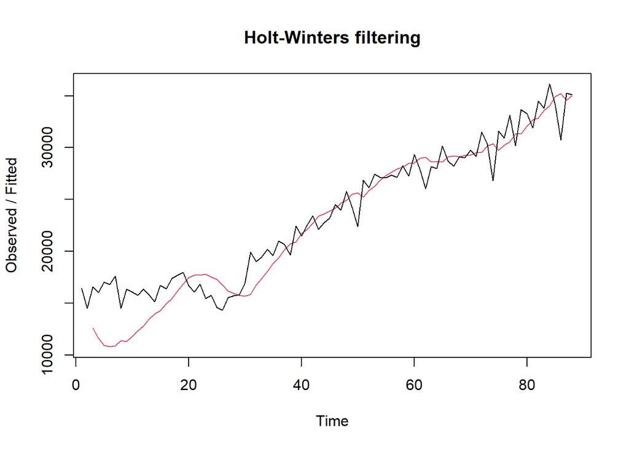

```r
#Lamda=0.2 dan gamma=0.2

des.1<- HoltWinters(train.ts, gamma = FALSE, beta = 0.2, alpha = 0.2)

plot(des.1)
```

```r
#ramalan
library(forecast)
ramalandes1<- forecast(des.1, h=12)

ramalandes1
```

```
##     Point Forecast    Lo 80    Hi 80    Lo 95    Hi 95
##  89       35355.90 32620.36 38091.45 31172.25 39539.56
##  90       35659.73 32846.51 38472.96 31357.28 39962.19
##  91       35963.56 33047.93 38879.20 31504.49 40422.64
##  92       36267.39 33223.19 39311.60 31611.68 40923.11
##  93       36571.22 33371.69 39770.76 31677.96 41464.49
##  94       36875.05 33493.59 40256.52 31703.54 42046.56
##  95       37178.88 33589.58 40768.18 31689.52 42668.25
##  96       37482.71 33660.78 41304.65 31637.57 43327.86
##  97       37786.54 33708.47 41864.62 31549.67 44023.42
##  98       38090.37 33734.07 42446.68 31427.98 44752.77
##  99       38394.20 33738.96 43049.45 31274.62 45513.79
## 100       38698.03 33724.46 43671.61 31091.61 46304.46
```

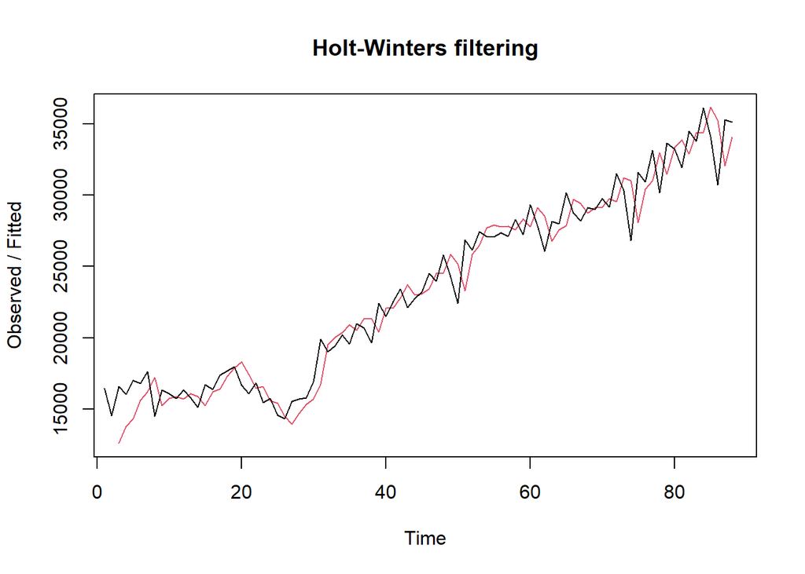

```r
#Lamda=0.6 dan gamma=0.3

des.2<- HoltWinters(train.ts, gamma = FALSE, beta = 0.3, alpha = 0.6)

plot(des.2)
```

```r
#ramalan

ramalandes2<- forecast(des.2, h=12)

ramalandes2
```

```
##     Point Forecast    Lo 80    Hi 80    Lo 95    Hi 95
##  89       35001.11 32904.99 37097.23 31795.37 38206.85
##  90       35288.00 32629.64 37946.35 31222.40 39353.60
##  91       35574.89 32240.81 38908.97 30475.85 40673.93
##  92       35861.78 31759.81 39963.75 29588.36 42135.21
##  93       36148.67 31200.77 41096.58 28581.50 43715.84
##  94       36435.56 30573.17 42297.95 27469.81 45401.32
##  95       36722.45 29883.71 43561.20 26263.49 47181.41
##  96       37009.35 29137.31 44881.38 24970.11 49048.59
##  97       37296.24 28337.79 46254.69 23595.47 50997.00
##  98       37583.13 27488.19 47678.07 22144.25 53022.01
##  99       37870.02 26591.03 49149.01 20620.29 55119.74
## 100       38156.91 25648.44 50665.38 19026.85 57286.97
```

membandingkan plot data latih dan data uji adalah sebagai berikut.

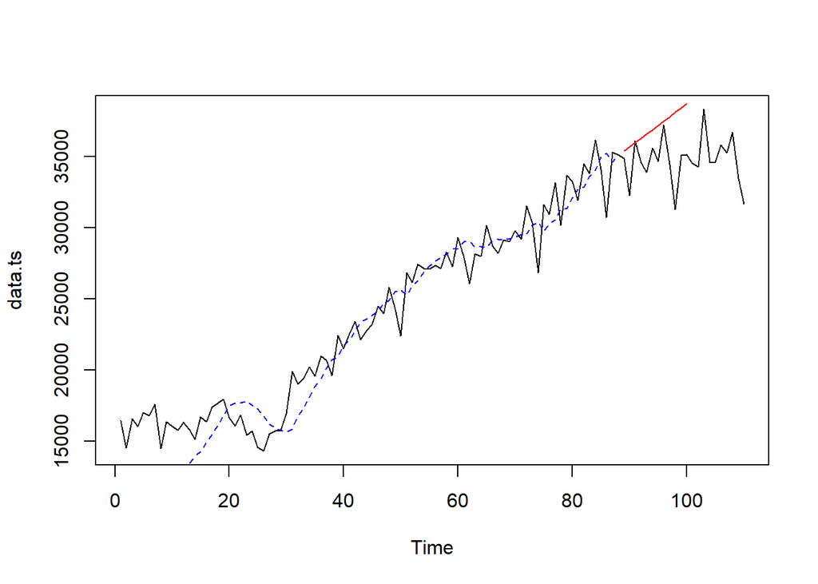

```r
#Visually evaluate the prediction

plot(data.ts)

lines(des.1$fitted[,1], lty=2, col="blue")

lines(ramalandes1$mean, col="red")
```

Untuk mendapatkan nilai parameter optimum dari DES, argumen `alpha` dan `beta` dapat dibuat `NULL` seperti berikut.

```r
#Lamda dan gamma optimum

des.opt<- HoltWinters(train.ts, gamma = FALSE)

des.opt
```

```
## Holt-Winters exponential smoothing with trend and without seasonal component.
##
## Call:
## HoltWinters(x = train.ts, gamma = FALSE)
##
## Smoothing parameters:
##  alpha: 0.5133202
##  beta : 0.2650597
##  gamma: FALSE
##
## Coefficients:
##         [,1]
## a 34648.7193
## b   230.7231
```

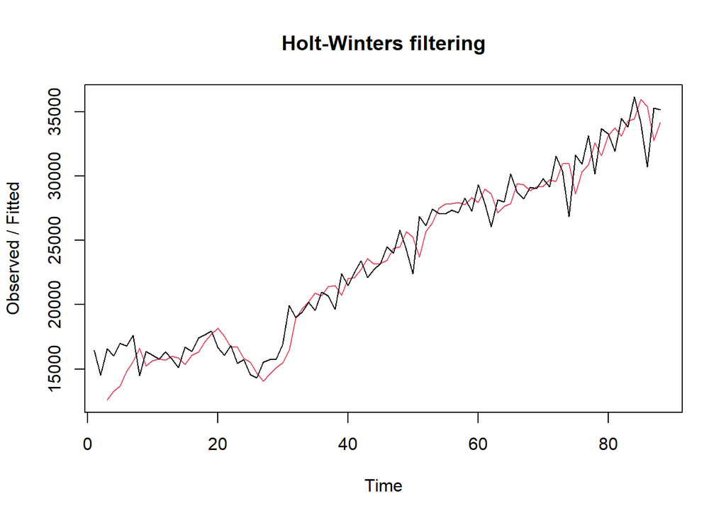

```r
plot(des.opt)
```

```r
#ramalan

ramalandesopt<- forecast(des.opt, h=12)

ramalandesopt
```

```
##     Point Forecast    Lo 80    Hi 80    Lo 95    Hi 95
##  89       34879.44 32814.33 36944.56 31721.12 38037.77
##  90       35110.17 32647.83 37572.50 31344.34 38875.99
##  91       35340.89 32392.31 38289.46 30831.43 39850.34
##  92       35571.61 32062.26 39080.96 30204.53 40938.70
##  93       35802.33 31668.89 39935.78 29480.78 42123.89
##  94       36033.06 31220.43 40845.69 28672.77 43393.34
##  95       36263.78 30722.87 41804.69 27789.69 44737.87
##  96       36494.50 30180.71 42808.30 26838.39 46150.62
##  97       36725.23 29597.38 43853.08 25824.12 47626.33
##  98       36955.95 28975.57 44936.33 24751.02 49160.88
##  99       37186.67 28317.49 46055.85 23622.43 50750.91
## 100       37417.40 27624.95 47209.84 22441.15 52393.64
```

### Akurasi Data Latih

```r
#Akurasi Data Training

ssedes.train1<-des.1$SSE

msedes.train1<-ssedes.train1/length(train.ts)

sisaandes1<-ramalandes1$residuals

head(sisaandes1)
```

```
## Time Series:
## Start = 1
## End = 6
## Frequency = 1
## [1]       NA       NA 3992.000 4407.920 6104.339 6018.301
```

```r
mapedes.train1 <- sum(abs(sisaandes1[3:length(train.ts)]/train.ts[3:length(train.ts)])

                      *100)/length(train.ts)

akurasides.1 <- matrix(c(ssedes.train1,msedes.train1,mapedes.train1))

row.names(akurasides.1)<- c("SSE", "MSE", "MAPE")

colnames(akurasides.1) <- c("Akurasi lamda=0.2 dan gamma=0.2")

akurasides.1
```

```
##      Akurasi lamda=0.2 dan gamma=0.2
## SSE                     4.234552e+08
## MSE                     4.811991e+06
## MAPE                    8.160178e+00
```

```r
ssedes.train2<-des.2$SSE

msedes.train2<-ssedes.train2/length(train.ts)

sisaandes2<-ramalandes2$residuals

head(sisaandes2)
```

```
## Time Series:
## Start = 1
## End = 6
## Frequency = 1
## [1]       NA       NA 3992.000 2252.240 2690.933 1183.042
```

```r
mapedes.train2 <- sum(abs(sisaandes2[3:length(train.ts)]/train.ts[3:length(train.ts)])

                      *100)/length(train.ts)

akurasides.2 <- matrix(c(ssedes.train2,msedes.train2,mapedes.train2))

row.names(akurasides.2)<- c("SSE", "MSE", "MAPE")

colnames(akurasides.2) <- c("Akurasi lamda=0.6 dan gamma=0.3")

akurasides.2
```

```
##      Akurasi lamda=0.6 dan gamma=0.3
## SSE                     2.291528e+08
## MSE                     2.604009e+06
## MAPE                    5.423298e+00
```

Kesimpulan:

Akurasi data lathi dengan lamda = 0.6 dan gamma = 0.3 memiliki hasil peramalan sangat baik berdasarkan nilai MAPE-nya